# Bootstrapping basics

### Example 0: Bootstrapping $\mathrm{Var}[\bar{X}]$.

```r
n <- 100
X <- rnorm(n, mean = 1, sd = 1) ## Standard deviation of \bar{X} is 1/sqrt(n)
B <- 1000
Xbar.bootstrap <- numeric(B)
for(b in 1:B){
  Xb <- X[sample(1:n,n,replace = TRUE)]
  Xbar.bootstrap[b] <- mean(Xb)
}
## Equivalently
## Xbar.bootstrap <- sapply(1:B, function() mean(X[sample(n,n,replace = TRUE)]))
sd.Xbar <- sd(Xbar.bootstrap)
sd.Xbar
```

```
## [1] 0.1019764
```

### Example 1: Parametric bootstrapping

```r
library(boot)
data(aircondit)
aircondit
```

```
##    hours
## 1      3
## 2      5
## 3      7
## 4     18
## 5     43
## 6     85
## 7     91
## 8     98
## 9    100
## 10   130
## 11   230
## 12   487
```

The *aircondit* data frame reported $n = 12$ times between failures of the air-conditioning equipment in several Boeing 720 aircrafts. We wish to estimate the underlying mean time to next failure. A simple model for this problem is that the times are sampled from an exponential distribution
$$f(x; \lambda) = \begin{cases} \lambda e^{- \lambda x} & \text{if $x \geq 0$} \\ 0 & \text{if $x < 0$} \end{cases}$$
The parameter $\lambda$ is the *failure rate* and $\theta = 1/\lambda$ is the mean time to the next failure.

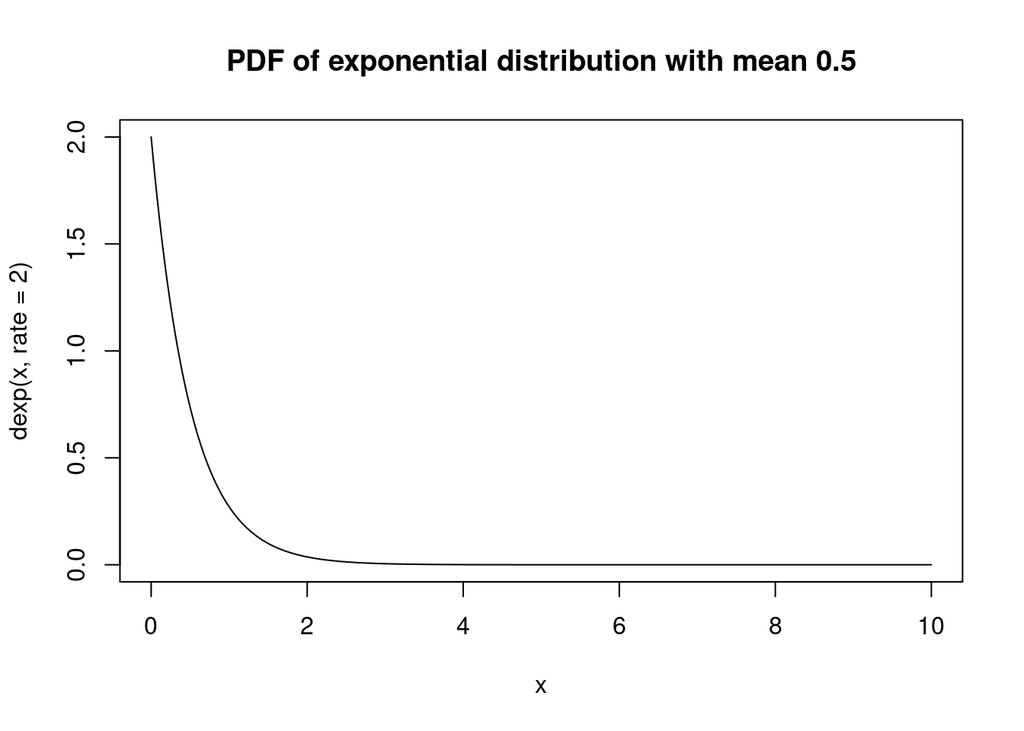

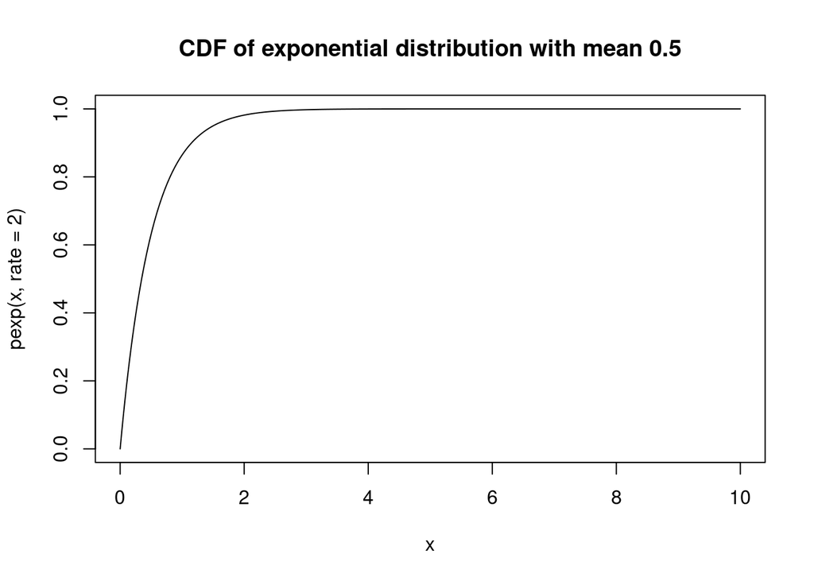

```r
x <- seq(from = 0, to = 10, by = 0.01)
plot(x, dexp(x, rate = 2), type = "l", main = "PDF of exponential distribution with mean 0.5")
plot(x, pexp(x, rate = 2), type = "l", main = "CDF of exponential distribution with mean 0.5")
```

Fitting an exponential distribution (via maximume likelihood estimation) to the *aircondit* dataset yield $\widehat{\theta} = \bar{Y} = 108.083$.

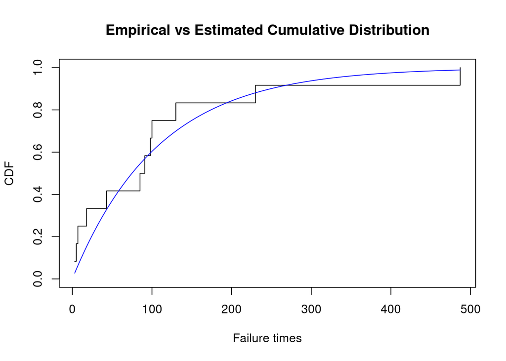

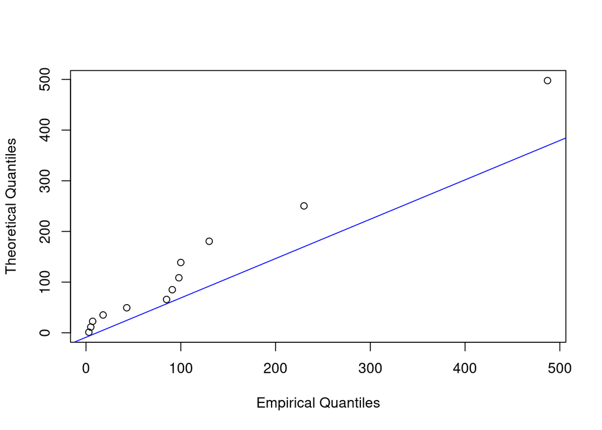

```r
n <- 12
plot(aircondit$hours, (1:n)/n, type = 's', ylim = c(0, 1), xlab = 'Failure times',
     ylab = 'CDF', main = 'Empirical vs Estimated Cumulative Distribution')

xseq <- seq(from = min(aircondit$hours), to = max(aircondit$hours), by = 1)
lines(xseq, pexp(xseq, rate = 1/mean(aircondit$hours)), col = "blue")
qqplot(aircondit$hours,qexp(ppoints(50),rate = 1/mean(aircondit$hours)),
       xlab = "Empirical Quantiles", ylab = "Theoretical Quantiles")
qqline(aircondit$hours, distribution = function(p) qexp(p, rate = 1/mean(aircondit$hours)), col = "blue")
```

Suppose now we want a $95\%$ confidence interval for $\widehat{\theta}$.

```r
B <- 1000
n <- 12
bvec <- numeric(B)
hat.theta <- mean(aircondit$hours)
for(i in 1:B){
  hours.i <- rexp(n, 1/hat.theta)
  bvec[i] <- mean(hours.i)
}
quantile(bvec,probs = c(0.025,0.975))
```

```
##      2.5%     97.5%
##  55.06702 173.81341
```

### Example 2: nonparametric bootstrapping

```r
library(boot)
data(bigcity)
head(bigcity, n = 10)
```

```
##      u   x
## 1  138 143
## 2   93 104
## 3   61  69
## 4  179 260
## 5   48  75
## 6   37  63
## 7   29  50
## 8   23  48
## 9   30 111
## 10   2  50
```

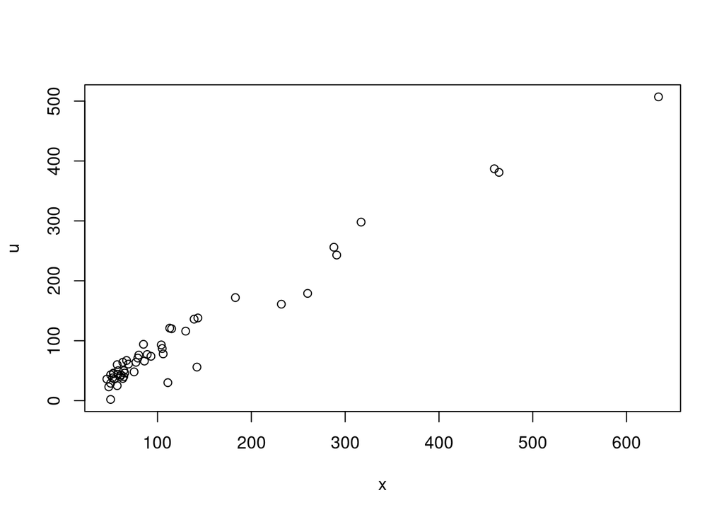

```r
plot(u ~ x, bigcity)
```

The *bigcity* data frame records the population (in 1000’s) of $49$ U.S. cities in $1920$ and $1930$. The $49$ cities are a random sample taken from the $196$ largest cities in the U.S. in 1920. If we assume the cities form a random sample $(U,X)$, then we are interested in the parameter $\theta = \mathbb{E}[X]/\mathbb{E}[U]$ — the ratio of the means — as this would enable us to estimate the total population in the U.S. in $1930$ from the $1920$ figure.

A natural estimate of $\theta$ is $\widehat{\theta} = \bar{X}/\bar{U} = 127.796/103.143 \approx 1.239$. We would like to get an estimate of $\mathrm{Var}[\widehat{\theta}]$. In contrast to the *aircondit* dataset in Example 1, it is not clear what parametric model one can assume for the joint distribution of $(U,X)$. We therefore resort to a non-parametric bootstrap estimate for $\mathrm{Var}[\widehat{\theta}]$.

```r
n <- nrow(bigcity)
nmc <- 1000
theta.vec <- numeric(nmc)
for(i in 1:nmc){
  idx.i <- sample(1:n, replace = TRUE)
  theta.vec[i] <- mean(bigcity$x[idx.i])/mean(bigcity$u[idx.i])
}
estimated.var <- var(theta.vec)
```

The non-parametric bootstrap estimate yield $\widehat{\mathrm{Var}}[\widehat{\theta}] = 0.0013$ and a $95\%$ confidence interval for $\widehat{\theta}$ of $(1.174, 1.311)$.

### Example 3: Testing of differences

```r
library(boot)
data(darwin)
darwin
```

```
##      y
## 1   49
## 2  -67
## 3    8
## 4   16
## 5    6
## 6   23
## 7   28
## 8   41
## 9   14
## 10  29
## 11  56
## 12  24
## 13  75
## 14  60
## 15 -48
```

The *darwin* data frame contains $15$ observations from an experiment by Charles Darwin to examine the superiority of cross-fertilized plants over self-fertilized plants. Each observation consisted of one cross-fertilized plant and one self-fertilized plant which germinated at the same time and grew in the same pot. The plants were measured at a fixed time after planting and the difference in heights between the cross- and self-fertilized plants are recorded in eighths of an inch. We are interested in testing the null hypothesis of no treatment difference between cross-fertilized plants over self-fertilized plants. Vieweing the $Y_i$ as i.i.d. $F$ for some symmetric distribution $F$, this can be formulated as testing the null hypothesis $\mathbb{H}_0 \colon \mu_F = 0$ against the alternative hypothesis that $\mathbb{H}_1 \colon \mu_F > 0$. We emphasize that no parametric assumption is made regarding $F$, other than that it is symmetric around $0$.

A reasonable test statistic is then $T = \bar{Y}$. For this dataset, $T = 20.933$. To obtain the critical value for $T$ under $\mathbb{H}_0$, we can think of “permuting”/“swapping” the label of the plants from a single observation. More specifically

```r
nmc <- 1000
T <- mean(darwin$y)
n <- length(darwin$y)
T.vec <- numeric(nmc)
for(i in 1:nmc){
  labels.i <- rbinom(n,1,0.5)*2 - 1
  T.vec[i] <- mean(labels.i*darwin$y)
}
cv <- quantile(T.vec, probs = c(0.95,0.99))
cv
```

```
##      95%      99%
## 18.13333 24.93467
```

Thus, for this problem, we will reject the null hypothesis $\mathbb{H}_0$ at significance level $\alpha = 0.05$ and conclude that there is some evidence that there is a positive difference between cross-fertilized and self-fertilized plants.

### Example 4: Correlation test

```r
library(boot)
data(claridge)
head(claridge, n = 15)
```

```
##    dnan hand
## 1    13    1
## 2    18    1
## 3    20    3
## 4    21    1
## 5    21    1
## 6    24    1
## 7    24    1
## 8    27    1
## 9    28    1
## 10   28    2
## 11   28    1
## 12   28    2
## 13   28    1
## 14   28    4
## 15   28    1
```

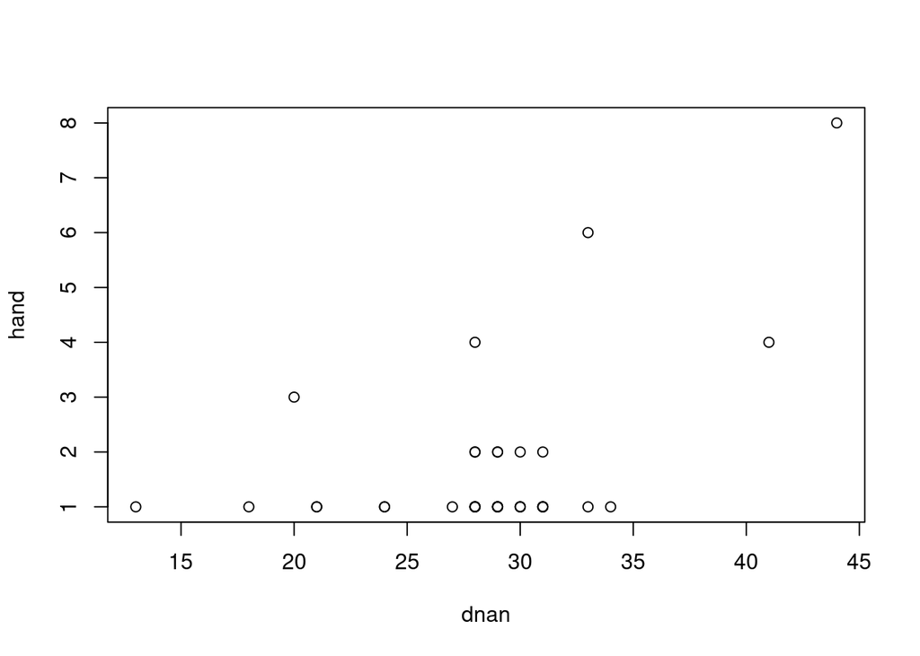

```r
plot(hand ~ dnan, claridge)
```

The *claridge* data frame contains observations from an experiment designed to look for a relationship between certain genetic characteristic and left-handedness. $37$ subjects (mother with children) were enrolled in the study, and for each mother, a genetic measurement of their DNA was made. Larger values of this measurement are hypothesized to be linked to a progressive shift away from right-handednessas measured in a scale rangin from $1$ (always favouring the right hand) to $8$ (always favoring the left hand). Suppose we are interested in determining whether such a link exist. Denoting each observation as a sample from a random pair $(U,X)$, we formulate this as a test of the null hypothesis $\mathbb{H}_0 \colon \text{$U$ and $X$ are independent}$ against the alternative hypothesis that $\mathbb{H}_1 \colon \text{$U$ is larger as $X$ increases}$.

A reasonable test statistic for this problem is then the sample Pearson correlation
$$\widehat{\rho} = \frac{\sum_{i=1}^{n} (U_i - \bar{U}) (X_i - \bar{X})}{\sqrt{
\sum_{i=1}^{n} (U_i - \bar{U})^2}\sqrt{
\sum_{i=1}^{n} (X_i - \bar{X}})^2} \approx 0.509$$
If the pair $(U,X)$ is bivariate normal with correlation $\rho$, then $\sqrt{n}(\widehat{\rho} - \rho)$ is asymptotically normally distributed with mean $0$ and variance $(1 - \rho^2)^2$. However, for the *claridge* data, we see that the assumption of bivariate normality for $(U,X)$ is untenable.

We resort to a permutation test. We can think of permuting the labels of the $U_i$ while keeping the labels of the $X_i$ fixed. If the null hypothesis is true, i.e., that $U$ and $X$ are independent, then permuting the labels of the $U_i$ will still preserve the independence. More specifically,

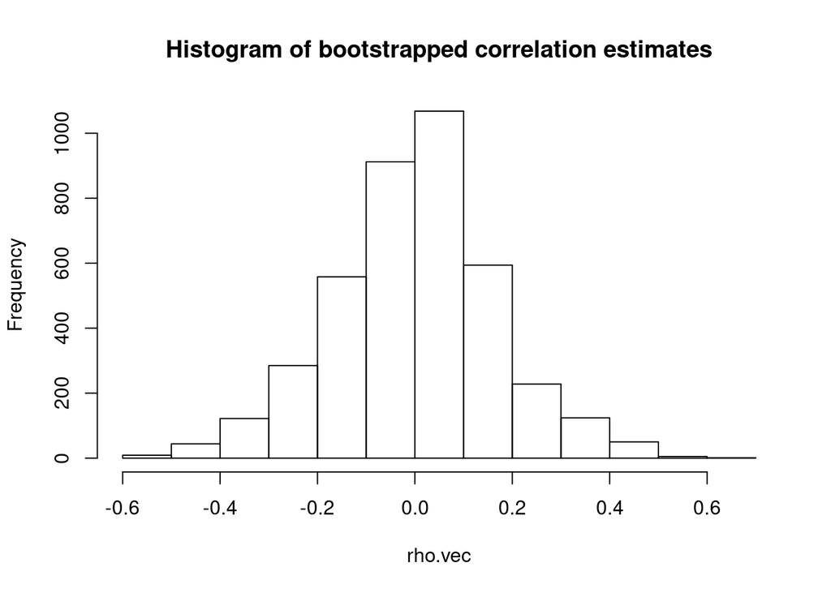

```r
n <- nrow(claridge)
nmc <- 4000
rho.vec <- numeric(nmc)
for(i in 1:nmc){
  idx.i <- sample(1:n)
  rho.vec[i] <- cor(claridge$dnan[idx.i],claridge$hand)
}
hist(rho.vec,main = "Histogram of bootstrapped correlation estimates")
```

```r
cv <- quantile(rho.vec,probs=c(0.95,0.99))
cv
```

```
##       95%       99%
## 0.2869191 0.4260266
```

Thus, for this problem, we will reject the null hypothesis at significance level $\alpha = 0.01$ and conclude that there is strong evidence that larger value of $U$ is associated with larger value of $X$.

### Example 5: Bootstrap estimate of the median

```r
set.seed(123)
n <- 300
X <- rnorm(n)
nmc <- 10000
med.vec <- numeric(nmc)
for(i in 1:nmc){
  idx.i <- sample(1:n, replace = TRUE)
  med.vec[i] <- median(X[idx.i])
}
var.median <- var(med.vec)
n*var.median ## Theoretical value in this case is pi/2 \approx 1.571
```

```
## [1] 1.712881
```

```r
n <- 3000
X <- rnorm(n)
nmc <- 10000
med.vec <- numeric(nmc)
for(i in 1:nmc){
  idx.i <- sample(1:n, replace = TRUE)
  med.vec[i] <- median(X[idx.i])
}
var.median <- var(med.vec)
n*var.median ## Theoretical value in this case is pi/2 \approx 1.571
```

```
## [1] 1.755149
```

```r
n <- 10000
X <- rnorm(n)
nmc <- 10000
med.vec <- numeric(nmc)
for(i in 1:nmc){
  idx.i <- sample(1:n, replace = TRUE)
  med.vec[i] <- median(X[idx.i])
}
var.median <- var(med.vec)
n*var.median ## Theoretical value in this case is pi/2 \approx 1.571
```

```
## [1] 1.282706
```

### Example 6: Bootstrapping regression

```r
library(MASS)
library(car)
data(Duncan)
mod.duncan <- rlm(prestige ~ income + education, data = Duncan)
summary(mod.duncan)
```

```
##
## Call: rlm(formula = prestige ~ income + education, data = Duncan)
## Residuals:
##     Min      1Q  Median      3Q     Max
## -30.120  -6.889   1.291   4.592  38.603
##
## Coefficients:
##             Value   Std. Error t value
## (Intercept) -7.1107  3.8813    -1.8320
## income       0.7014  0.1087     6.4516
## education    0.4854  0.0893     5.4380
##
## Residual standard error: 9.892 on 42 degrees of freedom
```

We now consider bootstrapping using cases-resampling

```r
boot.huber <- function(data, indices, maxit = 20){
dat.i <- data[indices,]
mod <- rlm(prestige ~ income + education, dat.i, maxit = maxit)
coefficients(mod)
}
duncan.boot <- boot(Duncan, boot.huber, 999, maxit = 100)
duncan.boot
```

```
##
## ORDINARY NONPARAMETRIC BOOTSTRAP
##
##
## Call:
## boot(data = Duncan, statistic = boot.huber, R = 999, maxit = 100)
##
##
## Bootstrap Statistics :
##       original       bias    std. error
## t1* -7.1107028  0.054598490   3.0132246
## t2*  0.7014493 -0.010111455   0.1709955
## t3*  0.4854390  0.005245772   0.1325048
```

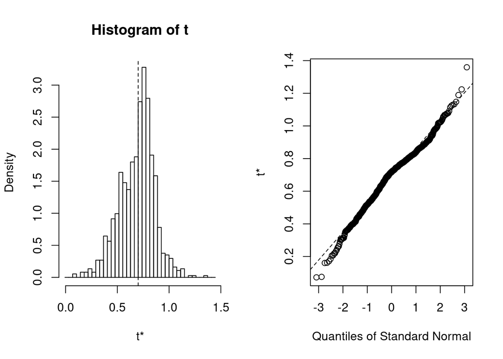

```r
plot(duncan.boot, index = 2)
```

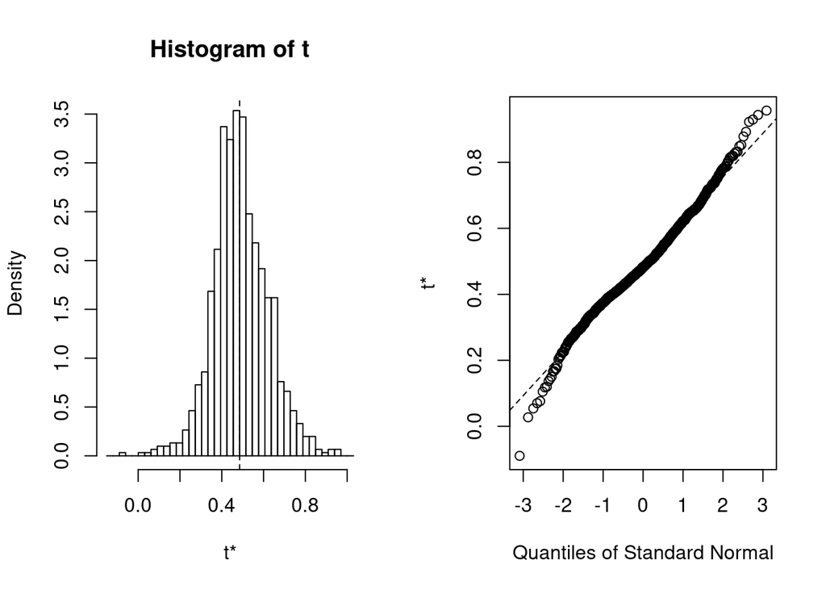

```r
plot(duncan.boot, index = 3)
```

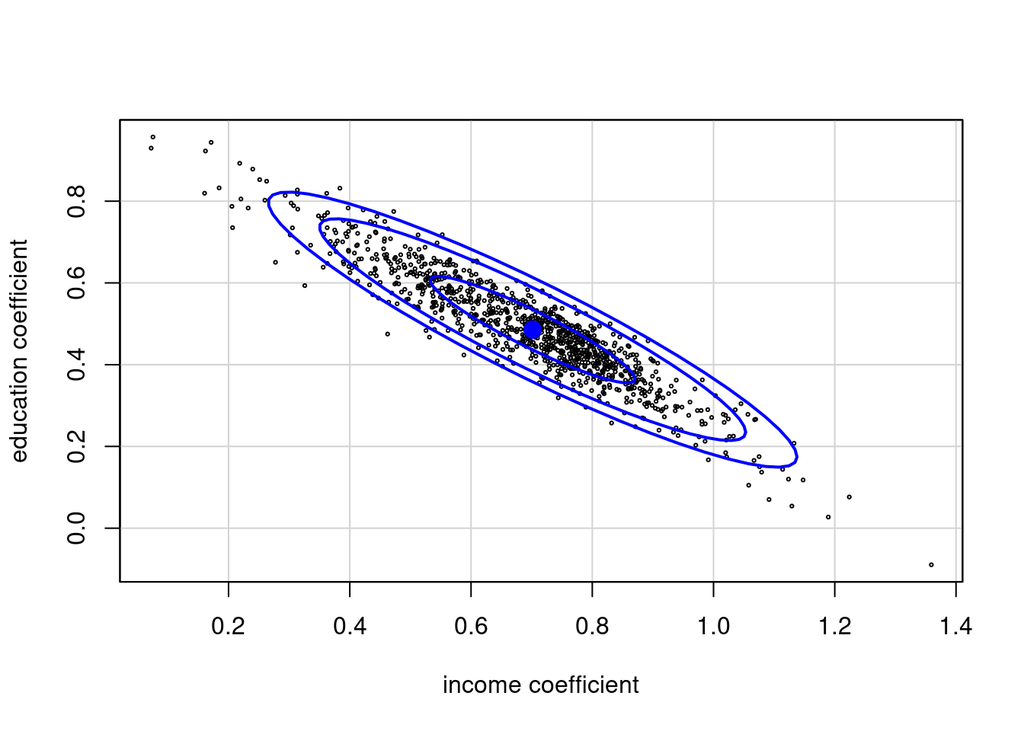

```r
dataEllipse(duncan.boot$t[,2], duncan.boot$t[,3], xlab="income coefficient",
             ylab="education coefficient", cex=.3, levels=c(.5, .95, .99), robust=T)
```

We next consider bootstrapping using fixed-$x$-resampling

```r
fit <- fitted(mod.duncan)
e <- residuals(mod.duncan)
X <- model.matrix(mod.duncan)
boot.huber.fixed <- function(data, indices, maxit=20){
y <- fit + e[indices]
mod <- rlm(y ~ X - 1, maxit=maxit)
coefficients(mod)
}
duncan.fix.boot <- boot(Duncan, boot.huber.fixed, 1999, maxit=100)
duncan.fix.boot
```

```
##
## ORDINARY NONPARAMETRIC BOOTSTRAP
##
##
## Call:
## boot(data = Duncan, statistic = boot.huber.fixed, R = 1999, maxit = 100)
##
##
## Bootstrap Statistics :
##       original        bias    std. error
## t1* -7.1107028 -0.0943995279  3.74870438
## t2*  0.7014493 -0.0001227943  0.10833302
## t3*  0.4854390  0.0014055074  0.08651273
```

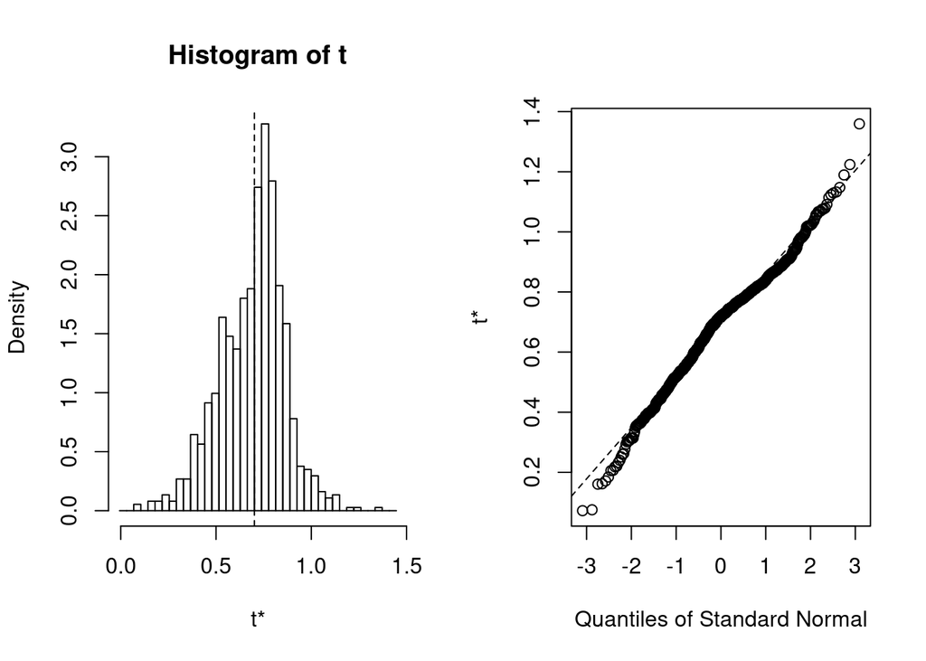

```r
plot(duncan.boot, index = 2)
```

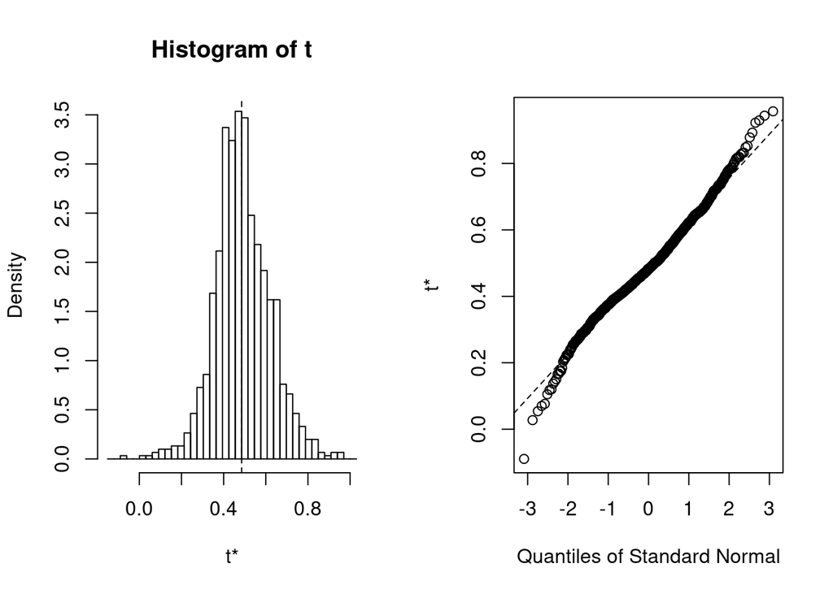

```r
plot(duncan.boot, index = 3)
```

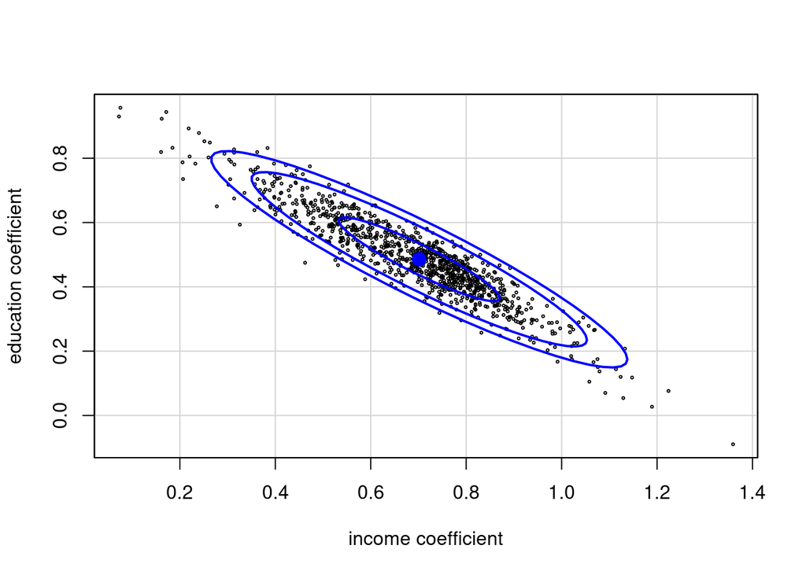

```r
dataEllipse(duncan.boot$t[,2], duncan.boot$t[,3], xlab="income coefficient",
             ylab="education coefficient", cex=.3, levels=c(.5, .95, .99), robust=T)
```

We are now interested in testing say the null hypothesis $\mathbb{H}_0 \colon \beta_1 = \beta_2$ agains the alternative hypothesis that $\mathbb{H}_1 \colon \beta_1 \not = \beta_2$.

```r
b <- coefficients(mod.duncan)
sumry <- summary(mod.duncan)
V <- sumry$cov.unscaled * sumry$stddev^2
L <- c(0,1,-1)
b1 <- b[2] - b[3]
(t <- b1/sqrt(L %*% V %*% L)) ## Test statistic from the fitted model
```

```
##          [,1]
## [1,] 1.174007
```

```r
## Now let us bootstrap
boot.test <- function(data, indices, maxit=20){
  data <- data[indices,]
  mod <- rlm(prestige ~ income + education, data=data, maxit=maxit)
  sumry <- summary(mod)
  V.star <- sumry$cov.unscaled * sumry$stddev^2
  b.star <- coefficients(mod)
  b1.star <- b.star[2] - b.star[3]
  ## Be careful here, we have to properly pivot our test statistic.
  t <- (b1.star - b1)/sqrt(L %*% V.star %*% L)
  t
}
duncan.test.boot <- boot(Duncan, boot.test, 999, maxit=100)
summary(duncan.test.boot$t)
```

```
##        V1
##  Min.   :-8.75613
##  1st Qu.:-1.12847
##  Median : 0.16931
##  Mean   :-0.07283
##  3rd Qu.: 1.05249
##  Max.   : 6.44031
```

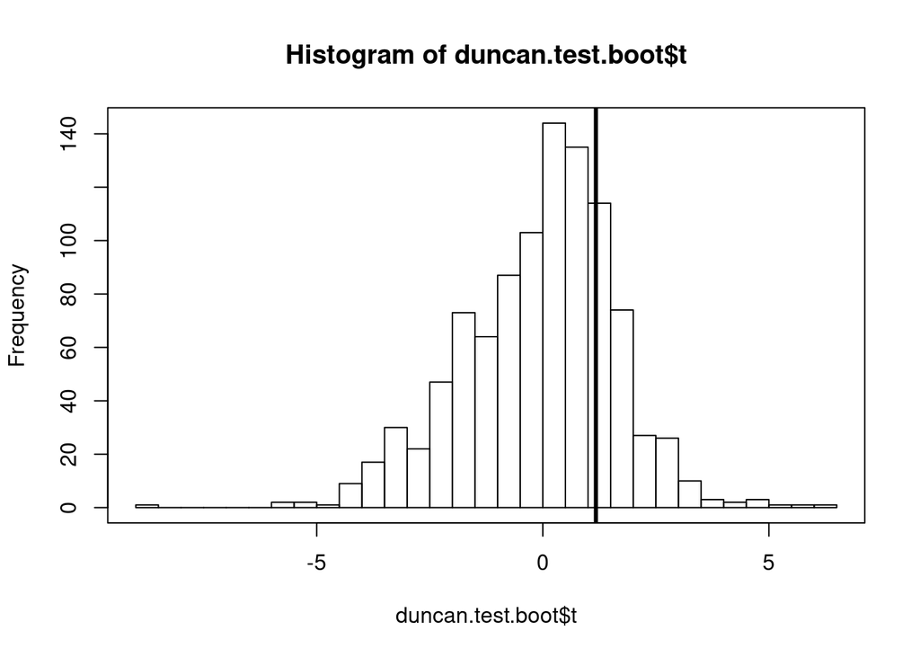

```r
hist(duncan.test.boot$t, breaks=50)
box()
abline(v=t, lwd=3)
```

```r
2*pnorm(t, lower.tail = FALSE) ## p-value under asymptotic limiting theory
```

```
##          [,1]
## [1,] 0.240392
```

```r
2*(1 + sum(duncan.test.boot$t > as.vector(t)))/1000 ## Bootstrapped p-value
```

```
## [1] 0.444
```